# DID on the foreigh labour

這篇文章使用人力運用調查資料，並以OLS/WLS 以及 DID進行分析。

```python
import numpy as np
import pandas as pd
import matplotlib.pyplot as plt
from pandas import CategoricalDtype
from unicodedata import decimal

path = ".\\Data\\MainData_ind16_clean_includeyear.csv"
df = pd.read_csv(path)
df.head()
```

|  | gender | age | marriage | labour1 | working_hour | employed | weight | scale | eduyear | exp | ... | 2010 | 2011 | 2012 | 2013 | 2014 | 2015 | 2016 | 2017 | 2018 | 2019 |
| --- | --- | --- | --- | --- | --- | --- | --- | --- | --- | --- | --- | --- | --- | --- | --- | --- | --- | --- | --- | --- | --- |
| 0 | 1.0 | 45.0 | 2.0 | 1.0 | 72.0 | 2.0 | 317.0 | 1.0 | 16 | 77.0 | ... | 0 | 0 | 0 | 0 | 0 | 0 | 0 | 0 | 0 | 0 |
| 1 | 1.0 | 41.0 | 2.0 | 1.0 | 60.0 | 1.0 | 311.0 | 2.0 | 16 | 156.0 | ... | 0 | 0 | 0 | 0 | 0 | 0 | 0 | 0 | 0 | 0 |
| 2 | 1.0 | 26.0 | 1.0 | 1.0 | 60.0 | 4.0 | 467.0 | 7.0 | 16 | 9.0 | ... | 0 | 0 | 0 | 0 | 0 | 0 | 0 | 0 | 0 | 0 |
| 3 | 1.0 | 40.0 | 2.0 | 1.0 | 60.0 | 1.0 | 422.0 | 2.0 | 16 | 144.0 | ... | 0 | 0 | 0 | 0 | 0 | 0 | 0 | 0 | 0 | 0 |
| 4 | 1.0 | 35.0 | 2.0 | 1.0 | 70.0 | 1.0 | 294.0 | 2.0 | 16 | 28.0 | ... | 0 | 0 | 0 | 0 | 0 | 0 | 0 | 0 | 0 | 0 |

5 rows × 43 columns

```python
## 對資料進行處理
df = df.drop(columns=['wage','labour1'])

df = df.astype({'gender': 'category'})
df['gender'] = df['gender'].map({1.0:'male', 2.0:'female'})

df = df.astype({'marriage': 'category'})
df['marriage'] = df['marriage'].map({1.0:'unmarried', 2.0:'married', 3.0:'divorced', 4.0:'widowed'})

df = df.astype({'employed': 'category'})
df['employed'] = df['employed'].map({1.0:'employer', 2.0:'self-emp', 3.0:'gov-emp', 4.0:'private-emp'})
df['Occupation'] = df['employed'].map({'private-emp':1,'employer':0,'self-emp':0, 'gov-emp':0})

df = df.astype({'scale': 'category'})
df['scale'] = df['scale'].map({1.0:'1',2.0:'2-9',3.0:'10-29',4.0:'30-49',5.0:'50-99',6.0:'100-199',7.0:'200-499',8.0:'500up',9.0:'gov'})
df['scale4'] = df['scale'].map({'1':'1-9','2-9':'1-9','10-29':'10-199','30-49':'10-199','50-99':'10-199','100-199':'10-199','gov':'gov','200-499':'200-499','500up':'500up'})

year_category = CategoricalDtype(categories=[1993+i for i in range(0,27)], ordered =True)
df['year'] = df['year'].astype(year_category)

df = df.astype({'ind16': 'category'})
df['ind16_name'] = df['ind16'].map({
    1.0: 'Agriculture, Forestry, Fishing, Mining, and Quarrying',
    2.0: 'Manufacturing',
    3.0: 'Electricity, Gas, Water Supply, and Pollution Control',
    4.0: 'Construction',
    5.0: 'Wholesale and Retail Trade',
    6.0: 'Transportation and Storage',
    7.0: 'Accommodation and Food Services',
    8.0: 'Publishing, Media Production, and Information Services',
    9.0: 'Financial and Insurance Services',
    10.0: 'Real Estate',
    11.0: 'Professional, Scientific, and Technical Services',
    12.0: 'Support Services',
    13.0: 'Public Administration and Defense; Mandatory Social Security',
    14.0: 'Education, Healthcare, and Social Work',
    15.0: 'Arts, Entertainment, and Recreation',
    16.0: 'Other Services'})
df['ind'] = df['ind16_name'].map({
    'Agriculture, Forestry, Fishing, Mining, and Quarrying': 'AgricultureForestryFishingMining',
    'Manufacturing': 'Manufacturing',
    'Electricity, Gas, Water Supply, and Pollution Control': 'ElectricityGasWaterSupply',
    'Construction': 'Construction',
    'Wholesale and Retail Trade': 'WholesaleRetailTrade',
    'Transportation and Storage': 'TransportStorage',
    'Accommodation and Food Services': 'AccommodationFoodServices',
    'Publishing, Media Production, and Information Services': 'PublishingMediaInformation',
    'Financial and Insurance Services': 'FinanceInsurance',
    'Real Estate': 'RealEstate',
    'Professional, Scientific, and Technical Services': 'ProfessionalScientificTechnical',
    'Support Services': 'SupportServices',
    'Public Administration and Defense; Mandatory Social Security': 'PublicAdminDefense',
    'Education, Healthcare, and Social Work': 'EducationHealthcareSocialWork',
    'Arts, Entertainment, and Recreation': 'ArtsEntertainmentRecreation',
    'Other Services': 'OtherServices'
})

df = df.astype({'ind': 'category'})
df.drop(columns=['ind16'], inplace=True)

df = df.astype({'county_revised': 'category'})
df['county'] = df['county_revised'].map({2.0:'Yilan',4.0:'Hsinchu',5.0:'Miaoli',7.0:'Changhua',8.0:'Nantou',9.0:'Yunlin',10.0:'Chiayi',13.0:'Pingtung',14.0:'Taitung',15.0:'Hualien',16.0:'Penghu',17.0:'Keelung',18.0:'Hsinchu City',20.0:'Chiayi City',63.0:'Taipei City',64.0:'Kaohsiung City',65.0:'New Taipei City',66.0:'Taichung City',67.0:'Tainan City',68.0:'Tauyuan'})
df['IsMunicipality'] = df['county_revised'].map({2.0:0, 4.0:0, 5.0:0, 7.0:0, 8.0:0, 9.0:0, 10.0:0,13.0:0,14.0:0,15.0:0,16.0:0,17.0:0,18.0:0,20.0:0,63.0:1,64.0:1,65.0:1,66.0:1,67.0:1,68.0:1})
df['Region'] = df['county_revised'].map({2.0:'North', 4.0:'North', 5.0:'North', 7.0:'Central', 8.0:'Central', 9.0:'Central', 10.0:'South',13.0:'South',14.0:'East',15.0:'East',16.0:'Island',17.0:'North',18.0:'North',20.0:'South',63.0:'North',64.0:'South',65.0:'North',66.0:'Central',67.0:'South',68.0:'North'})
df = df.astype({'Region': 'category', 'IsMunicipality': 'category', 'county': 'category'})

df.drop(columns=['county_revised'], inplace=True)

df['prof9'] = df['prof9'].map({
    1.0:'managers',
    2.0:'professionals',
    3.0:'technicians',
    4.0:'clerks',
    5.0:'service',
    6.0:'agriculture',
    7.0:'craftsmen',
    8.0:'MachineOperators',
    9.0:'elementary'})
df = df.astype({'prof9': 'category'})
```

```python
# variables specifying for regression
## dummies variables
dummies_var = ['gender','marriage','Occupation','Region','prof9','scale4','ind']
df_dummies = pd.get_dummies(df, columns = dummies_var)

dummies_to_exclude = ['gender_male','marriage_unmarried','Occupation_1','Region_North','ind_AgricultureForestryFishingMining','scale4_gov','2010','prof9_agriculture']
redundancy_vars = ['employed','county','scale','ind16_name','IsMunicipality']
staggered_vars = [
    'col_1993', 'col_1994', 'col_1995', 'col_1996', 'col_1997',
    'col_1998', 'col_1999', 'col_2000', 'col_2001', 'col_2002',
    'col_2003', 'col_2004', 'col_2005', 'col_2006', 'col_2007',
    'col_2008', 'col_2009', 'col_2011', 'col_2012', 'col_2013',
    'col_2014', 'col_2015', 'col_2016', 'col_2017', 'col_2018',
    'col_2019'
]

df_ana = df_dummies.drop(columns = dummies_to_exclude + redundancy_vars)

df_ana.rename(columns=lambda x: 'col_' + x if x[0].isdigit() else x.replace('-', '_'), inplace=True) # pure digits string column names are not allowed.
```

```python
# @hidden_cell
df_ana.columns
```

```
Index(['age', 'working_hour', 'weight', 'eduyear', 'exp', 'lnW', 'year',
       'col_1993', 'col_1994', 'col_1995', 'col_1996', 'col_1997', 'col_1998',
       'col_1999', 'col_2000', 'col_2001', 'col_2002', 'col_2003', 'col_2004',
       'col_2005', 'col_2006', 'col_2007', 'col_2008', 'col_2009', 'col_2011',
       'col_2012', 'col_2013', 'col_2014', 'col_2015', 'col_2016', 'col_2017',
       'col_2018', 'col_2019', 'gender_female', 'marriage_married',
       'marriage_divorced', 'marriage_widowed', 'Occupation_0',
       'Region_Central', 'Region_East', 'Region_Island', 'Region_South',
       'prof9_MachineOperators', 'prof9_clerks', 'prof9_craftsmen',
       'prof9_elementary', 'prof9_managers', 'prof9_professionals',
       'prof9_service', 'prof9_technicians', 'scale4_1_9', 'scale4_10_199',
       'scale4_200_499', 'scale4_500up', 'ind_Manufacturing',
       'ind_ElectricityGasWaterSupply', 'ind_Construction',
       'ind_WholesaleRetailTrade', 'ind_TransportStorage',
       'ind_AccommodationFoodServices', 'ind_PublishingMediaInformation',
       'ind_FinanceInsurance', 'ind_RealEstate',
       'ind_ProfessionalScientificTechnical', 'ind_SupportServices',
       'ind_PublicAdminDefense', 'ind_EducationHealthcareSocialWork',
       'ind_ArtsEntertainmentRecreation', 'ind_OtherServices'],
      dtype='object')
```

## DID

實作 difference in difference。

```python
# @hidden_cell
import statsmodels.formula.api as smf
```

```python
# @hidden_cell
df_did = df_ana.copy()

# implement the DID experiment design
df_did['time'] = df_ana['year'] >= 2011
df_did['treatment'] = df_ana['ind_Manufacturing'] # Since the only treatment unit is the manufacturing sector.
df_did['time_treatment'] = [ a and b for a,b in zip(df_did['time'],df_did['treatment'])]

# we first do not consider the individual effect of each year.
df_did = df_did.drop(columns = staggered_vars)
# drop all industry dummies for alleviating the collinearity with 'treatment' variable.
df_did = df_did.drop(columns = [col for col in df_did.columns if "ind_" in col])

# start fitting
did_formula = "lnW ~ " + " + ".join(df_did.drop(columns = ['lnW','weight','year']).columns)
model_did_lnW = smf.wls(did_formula, data = df_did, weights  = df_did['weight'])
result_did = model_did_lnW.fit()
```

```python
result_did.summary()
```

WLS Regression Results

| Dep. Variable: | lnW | R-squared: | 0.340 |
| --- | --- | --- | --- |
| Model: | WLS | Adj. R-squared: | 0.340 |
| Method: | Least Squares | F-statistic: | 1.377e+04 |
| Date: | Sun, 10 Nov 2024 | Prob (F-statistic): | 0.00 |
| Time: | 16:11:39 | Log-Likelihood: | -6.1720e+05 |
| No. Observations: | 749002 | AIC: | 1.234e+06 |
| Df Residuals: | 748973 | BIC: | 1.235e+06 |
| Df Model: | 28 |  |  |
| Covariance Type: | nonrobust |  |  |

|  | coef | std err | t | P>\|t\| | [0.025 | 0.975] |
| --- | --- | --- | --- | --- | --- | --- |
| Intercept | 4.4343 | 0.007 | 634.922 | 0.000 | 4.421 | 4.448 |
| gender_female[T.True] | -0.2285 | 0.001 | -170.481 | 0.000 | -0.231 | -0.226 |
| marriage_married[T.True] | 0.1271 | 0.002 | 81.480 | 0.000 | 0.124 | 0.130 |
| marriage_divorced[T.True] | 0.0825 | 0.003 | 26.349 | 0.000 | 0.076 | 0.089 |
| marriage_widowed[T.True] | 0.0188 | 0.005 | 3.984 | 0.000 | 0.010 | 0.028 |
| Occupation_0[T.True] | 0.0933 | 0.002 | 48.918 | 0.000 | 0.090 | 0.097 |
| Region_Central[T.True] | -0.0540 | 0.002 | -35.107 | 0.000 | -0.057 | -0.051 |
| Region_East[T.True] | -0.0741 | 0.004 | -19.324 | 0.000 | -0.082 | -0.067 |
| Region_Island[T.True] | -0.0022 | 0.010 | -0.234 | 0.815 | -0.021 | 0.017 |
| Region_South[T.True] | -0.0755 | 0.001 | -53.244 | 0.000 | -0.078 | -0.073 |
| prof9_MachineOperators[T.True] | 0.6954 | 0.003 | 198.878 | 0.000 | 0.689 | 0.702 |
| prof9_clerks[T.True] | 0.6866 | 0.004 | 182.840 | 0.000 | 0.679 | 0.694 |
| prof9_craftsmen[T.True] | 0.7797 | 0.003 | 230.352 | 0.000 | 0.773 | 0.786 |
| prof9_elementary[T.True] | 0.5151 | 0.004 | 130.603 | 0.000 | 0.507 | 0.523 |
| prof9_managers[T.True] | 1.1452 | 0.004 | 272.017 | 0.000 | 1.137 | 1.153 |
| prof9_professionals[T.True] | 0.9313 | 0.004 | 239.049 | 0.000 | 0.924 | 0.939 |
| prof9_service[T.True] | 0.6593 | 0.003 | 199.661 | 0.000 | 0.653 | 0.666 |
| prof9_technicians[T.True] | 0.8336 | 0.004 | 234.568 | 0.000 | 0.827 | 0.841 |
| scale4_1_9[T.True] | -0.1481 | 0.003 | -57.305 | 0.000 | -0.153 | -0.143 |
| scale4_10_199[T.True] | -0.0780 | 0.003 | -27.215 | 0.000 | -0.084 | -0.072 |
| scale4_200_499[T.True] | -0.0124 | 0.004 | -3.044 | 0.002 | -0.020 | -0.004 |
| scale4_500up[T.True] | 0.0073 | 0.004 | 2.072 | 0.038 | 0.000 | 0.014 |
| time[T.True] | 0.0967 | 0.002 | 62.969 | 0.000 | 0.094 | 0.100 |
| treatment[T.True] | -0.0683 | 0.002 | -35.586 | 0.000 | -0.072 | -0.065 |
| time_treatment[T.True] | -0.0169 | 0.003 | -6.232 | 0.000 | -0.022 | -0.012 |
| age | 0.0049 | 7.32e-05 | 67.493 | 0.000 | 0.005 | 0.005 |
| working_hour | -0.0142 | 7.68e-05 | -185.231 | 0.000 | -0.014 | -0.014 |
| eduyear | 0.0365 | 0.000 | 145.624 | 0.000 | 0.036 | 0.037 |
| exp | 0.0001 | 3.44e-06 | 35.805 | 0.000 | 0.000 | 0.000 |

| Omnibus: | 1152677.560 | Durbin-Watson: | 1.725 |
| --- | --- | --- | --- |
| Prob(Omnibus): | 0.000 | Jarque-Bera (JB): | 1479357411.874 |
| Skew: | -9.389 | Prob(JB): | 0.00 |
| Kurtosis: | 219.910 | Cond. No. | 3.86e+03 |

Notes:  
[1] Standard Errors assume that the covariance matrix of the errors is correctly specified.  
[2] The condition number is large, 3.86e+03. This might indicate that there are  
strong multicollinearity or other numerical problems.

我們可以聚焦於變數「time_treatment」的估計結果：此變數的估計係數即為DID設計的特徵。我們可以發現估計係數為-0.0169，且p值小於0.05(p-value = 0)，顯示政策實施之後，本國籍製造業勞工實質時薪統計上顯著地平均減少約1.69%。意味著引進外籍移工確實對本國勞工的薪資造成負面影響。

註：以人力運用調查資料而言，我們沒有辦法以DID分析雇用人數的變化，因為資料是以個人為單位。

### stagger DID

以下我們採用stagger DID 的分析技巧對薪資進行分析，即透過加入年分變數控制各年分對影響薪資的因子所造成的影響。

```python
# @hidden_cell
df_stagger_did = df_ana.copy()

# implement the DID experiment design
df_stagger_did['time'] = df_ana['year'] >= 2011
df_stagger_did['treatment'] = df_ana['ind_Manufacturing'] # Since the only treatment unit is the manufacturing sector.
df_stagger_did['time_treatment'] = [ a and b for a,b in zip(df_did['time'],df_stagger_did['treatment'])]

# This time we consider the individual effect of each year to control the interruption of temporary shock.
#df_stagger_did = df_stagger_did.drop(columns = staggered_vars)
# drop all industry dummies for alleviating the collinearity with 'treatment' variable.
df_stagger_did = df_stagger_did.drop(columns = [col for col in df_stagger_did.columns if "ind_" in col])

# start fitting
stagger_did_formula = "lnW ~ " + " + ".join(df_stagger_did.drop(columns = ['lnW','weight','year']).columns)
model_stagger_did_lnW = smf.wls(stagger_did_formula, data = df_stagger_did, weights  = df_stagger_did['weight'])
result_stagger_did = model_stagger_did_lnW.fit()
```

```python
result_stagger_did.summary()
```

WLS Regression Results

| Dep. Variable: | lnW | R-squared: | 0.349 |
| --- | --- | --- | --- |
| Model: | WLS | Adj. R-squared: | 0.349 |
| Method: | Least Squares | F-statistic: | 7568. |
| Date: | Sun, 10 Nov 2024 | Prob (F-statistic): | 0.00 |
| Time: | 16:11:44 | Log-Likelihood: | -6.1214e+05 |
| No. Observations: | 749002 | AIC: | 1.224e+06 |
| Df Residuals: | 748948 | BIC: | 1.225e+06 |
| Df Model: | 53 |  |  |
| Covariance Type: | nonrobust |  |  |

|  | coef | std err | t | P>\|t\| | [0.025 | 0.975] |
| --- | --- | --- | --- | --- | --- | --- |
| Intercept | 4.5079 | 0.008 | 583.329 | 0.000 | 4.493 | 4.523 |
| gender_female[T.True] | -0.2291 | 0.001 | -171.988 | 0.000 | -0.232 | -0.226 |
| marriage_married[T.True] | 0.1327 | 0.002 | 85.371 | 0.000 | 0.130 | 0.136 |
| marriage_divorced[T.True] | 0.0919 | 0.003 | 29.507 | 0.000 | 0.086 | 0.098 |
| marriage_widowed[T.True] | 0.0296 | 0.005 | 6.307 | 0.000 | 0.020 | 0.039 |
| Occupation_0[T.True] | 0.0911 | 0.002 | 47.612 | 0.000 | 0.087 | 0.095 |
| Region_Central[T.True] | -0.0560 | 0.002 | -36.690 | 0.000 | -0.059 | -0.053 |
| Region_East[T.True] | -0.0706 | 0.004 | -18.550 | 0.000 | -0.078 | -0.063 |
| Region_Island[T.True] | -0.0051 | 0.010 | -0.538 | 0.590 | -0.024 | 0.014 |
| Region_South[T.True] | -0.0764 | 0.001 | -54.255 | 0.000 | -0.079 | -0.074 |
| prof9_MachineOperators[T.True] | 0.7137 | 0.003 | 204.440 | 0.000 | 0.707 | 0.721 |
| prof9_clerks[T.True] | 0.7055 | 0.004 | 188.698 | 0.000 | 0.698 | 0.713 |
| prof9_craftsmen[T.True] | 0.7916 | 0.003 | 234.978 | 0.000 | 0.785 | 0.798 |
| prof9_elementary[T.True] | 0.5494 | 0.004 | 138.886 | 0.000 | 0.542 | 0.557 |
| prof9_managers[T.True] | 1.1716 | 0.004 | 279.297 | 0.000 | 1.163 | 1.180 |
| prof9_professionals[T.True] | 0.9559 | 0.004 | 246.306 | 0.000 | 0.948 | 0.964 |
| prof9_service[T.True] | 0.6768 | 0.003 | 204.857 | 0.000 | 0.670 | 0.683 |
| prof9_technicians[T.True] | 0.8538 | 0.004 | 241.201 | 0.000 | 0.847 | 0.861 |
| scale4_1_9[T.True] | -0.1433 | 0.003 | -55.584 | 0.000 | -0.148 | -0.138 |
| scale4_10_199[T.True] | -0.0699 | 0.003 | -24.417 | 0.000 | -0.075 | -0.064 |
| scale4_200_499[T.True] | -0.0081 | 0.004 | -2.016 | 0.044 | -0.016 | -0.000 |
| scale4_500up[T.True] | 0.0161 | 0.004 | 4.579 | 0.000 | 0.009 | 0.023 |
| time[T.True] | 0.0652 | 0.003 | 22.541 | 0.000 | 0.060 | 0.071 |
| treatment[T.True] | -0.0692 | 0.002 | -36.311 | 0.000 | -0.073 | -0.065 |
| time_treatment[T.True] | -0.0183 | 0.003 | -6.824 | 0.000 | -0.024 | -0.013 |
| age | 0.0022 | 8.05e-05 | 26.835 | 0.000 | 0.002 | 0.002 |
| working_hour | -0.0136 | 7.71e-05 | -176.605 | 0.000 | -0.014 | -0.013 |
| eduyear | 0.0338 | 0.000 | 131.627 | 0.000 | 0.033 | 0.034 |
| exp | 0.0005 | 7.24e-06 | 75.128 | 0.000 | 0.001 | 0.001 |
| col_1993 | -0.1727 | 0.005 | -38.272 | 0.000 | -0.182 | -0.164 |
| col_1994 | -0.0972 | 0.004 | -21.669 | 0.000 | -0.106 | -0.088 |
| col_1995 | -0.0523 | 0.004 | -11.721 | 0.000 | -0.061 | -0.044 |
| col_1996 | -0.0443 | 0.004 | -9.964 | 0.000 | -0.053 | -0.036 |
| col_1997 | -0.4883 | 0.008 | -65.015 | 0.000 | -0.503 | -0.474 |
| col_1998 | -0.0008 | 0.004 | -0.178 | 0.859 | -0.009 | 0.008 |
| col_1999 | -0.0073 | 0.004 | -1.681 | 0.093 | -0.016 | 0.001 |
| col_2000 | 0.0141 | 0.004 | 3.276 | 0.001 | 0.006 | 0.023 |
| col_2001 | -0.0078 | 0.004 | -1.806 | 0.071 | -0.016 | 0.001 |
| col_2002 | -0.0217 | 0.004 | -5.017 | 0.000 | -0.030 | -0.013 |
| col_2003 | -0.0428 | 0.004 | -9.960 | 0.000 | -0.051 | -0.034 |
| col_2004 | -0.0332 | 0.004 | -7.795 | 0.000 | -0.042 | -0.025 |
| col_2005 | -0.0078 | 0.004 | -1.845 | 0.065 | -0.016 | 0.000 |
| col_2006 | 0.0047 | 0.004 | 1.120 | 0.263 | -0.004 | 0.013 |
| col_2007 | 0.0080 | 0.004 | 1.909 | 0.056 | -0.000 | 0.016 |
| col_2008 | 0.0196 | 0.004 | 4.675 | 0.000 | 0.011 | 0.028 |
| col_2009 | -0.0194 | 0.004 | -4.604 | 0.000 | -0.028 | -0.011 |
| col_2011 | -0.0446 | 0.003 | -16.053 | 0.000 | -0.050 | -0.039 |
| col_2012 | -0.0433 | 0.003 | -15.704 | 0.000 | -0.049 | -0.038 |
| col_2013 | -0.0380 | 0.003 | -13.837 | 0.000 | -0.043 | -0.033 |
| col_2014 | -0.0214 | 0.003 | -7.849 | 0.000 | -0.027 | -0.016 |
| col_2015 | -0.0060 | 0.003 | -2.203 | 0.028 | -0.011 | -0.001 |
| col_2016 | 0.0224 | 0.003 | 8.257 | 0.000 | 0.017 | 0.028 |
| col_2017 | 0.0514 | 0.003 | 19.020 | 0.000 | 0.046 | 0.057 |
| col_2018 | 0.0650 | 0.003 | 24.120 | 0.000 | 0.060 | 0.070 |
| col_2019 | 0.0798 | 0.003 | 30.064 | 0.000 | 0.075 | 0.085 |

| Omnibus: | 1164798.115 | Durbin-Watson: | 1.736 |
| --- | --- | --- | --- |
| Prob(Omnibus): | 0.000 | Jarque-Bera (JB): | 1563162662.940 |
| Skew: | -9.585 | Prob(JB): | 0.00 |
| Kurtosis: | 225.981 | Cond. No. | 1.04e+18 |

Notes:  
[1] Standard Errors assume that the covariance matrix of the errors is correctly specified.  
[2] The smallest eigenvalue is 1.18e-23. This might indicate that there are  
strong multicollinearity problems or that the design matrix is singular.

可以發現time_treatment的估計係數為-0.0183，負面影響較did(-0.0169)更大。

### 其他變數的分析結果

#### 性別對薪資的影響

性別對薪資具有統計上顯著的影響，女性平均比男性少約22.9%的薪資。

#### 年分變數的控制效果

可以觀察到大部分的年分變數其係數估計之p值皆小於0.05，在政策實施前後(2008~2012)具有2%~4%的影響。

```python
compare_stagger_did = pd.DataFrame({"DID":[result_did.params['time_treatment[T.True]']], "stagger DID": [result_stagger_did.params['time_treatment[T.True]']]})
```

```python
compare_stagger_did
```

|  | DID | stagger DID |
| --- | --- | --- |
| 0 | -0.016859 | -0.01834 |

如上表所示，stagger DID 的估計效果為-0.0183，相較於DID的-0.0169有更大的絕對值，顯示控制各年分的效果後，我們發現引進外籍移工的負面影響較DID的估計還要多，但差別不大，皆不大於2%。

### DID(with smaller data)

下述分析僅採用政策實施前後兩年(2008,2009,2011,2012)之資料進行分析。

```python
# @hidden_cell
# This dataset contains only records 2 years before and after the policy implementation year.
df_did_small = df_ana.copy()
df_did_small['time'] = df_did_small['year'] >= 2011
df_did_small['treatment'] = df_did_small['ind_Manufacturing'] # Since the only treatment unit is the manufacturing sector.
df_did_small['time_treatment'] = [ a and b for a,b in zip(df_did_small['time'],df_did_small['treatment'])]

df_did_small = df_did_small.drop(columns = staggered_vars)
df_did_small = df_did_small.drop(columns = [col for col in df_did_small.columns if "ind_" in col])

df_did_small = df_did_small[df_did_small['year'].isin([2008,2009,2011,2012])]

did_small_formula = "lnW ~ " + " + ".join(df_did_small.drop(columns = ['lnW','weight','year']).columns)
model_did_small_lnW = smf.wls(did_small_formula, data = df_did_small, weights = df_did_small['weight'])
result_did_small = model_did_small_lnW.fit()
```

```python
result_did_small.summary()
```

WLS Regression Results

| Dep. Variable: | lnW | R-squared: | 0.360 |
| --- | --- | --- | --- |
| Model: | WLS | Adj. R-squared: | 0.360 |
| Method: | Least Squares | F-statistic: | 2155. |
| Date: | Sun, 10 Nov 2024 | Prob (F-statistic): | 0.00 |
| Time: | 16:11:45 | Log-Likelihood: | -80118. |
| No. Observations: | 107307 | AIC: | 1.603e+05 |
| Df Residuals: | 107278 | BIC: | 1.606e+05 |
| Df Model: | 28 |  |  |
| Covariance Type: | nonrobust |  |  |

|  | coef | std err | t | P>\|t\| | [0.025 | 0.975] |
| --- | --- | --- | --- | --- | --- | --- |
| Intercept | 4.6198 | 0.018 | 254.142 | 0.000 | 4.584 | 4.655 |
| gender_female[T.True] | -0.1982 | 0.003 | -61.194 | 0.000 | -0.205 | -0.192 |
| marriage_married[T.True] | 0.1183 | 0.004 | 30.960 | 0.000 | 0.111 | 0.126 |
| marriage_divorced[T.True] | 0.0825 | 0.007 | 11.207 | 0.000 | 0.068 | 0.097 |
| marriage_widowed[T.True] | 0.0138 | 0.012 | 1.165 | 0.244 | -0.009 | 0.037 |
| Occupation_0[T.True] | 0.0880 | 0.005 | 17.870 | 0.000 | 0.078 | 0.098 |
| Region_Central[T.True] | -0.0703 | 0.004 | -18.676 | 0.000 | -0.078 | -0.063 |
| Region_East[T.True] | -0.0426 | 0.010 | -4.417 | 0.000 | -0.062 | -0.024 |
| Region_Island[T.True] | -0.0385 | 0.024 | -1.617 | 0.106 | -0.085 | 0.008 |
| Region_South[T.True] | -0.0929 | 0.003 | -26.715 | 0.000 | -0.100 | -0.086 |
| prof9_MachineOperators[T.True] | 0.6570 | 0.009 | 70.766 | 0.000 | 0.639 | 0.675 |
| prof9_clerks[T.True] | 0.6325 | 0.010 | 64.390 | 0.000 | 0.613 | 0.652 |
| prof9_craftsmen[T.True] | 0.7203 | 0.009 | 79.844 | 0.000 | 0.703 | 0.738 |
| prof9_elementary[T.True] | 0.4780 | 0.010 | 45.812 | 0.000 | 0.458 | 0.498 |
| prof9_managers[T.True] | 1.1406 | 0.011 | 104.762 | 0.000 | 1.119 | 1.162 |
| prof9_professionals[T.True] | 0.9017 | 0.010 | 89.865 | 0.000 | 0.882 | 0.921 |
| prof9_service[T.True] | 0.6210 | 0.009 | 70.420 | 0.000 | 0.604 | 0.638 |
| prof9_technicians[T.True] | 0.7963 | 0.009 | 85.605 | 0.000 | 0.778 | 0.815 |
| scale4_1_9[T.True] | -0.1682 | 0.006 | -26.449 | 0.000 | -0.181 | -0.156 |
| scale4_10_199[T.True] | -0.0844 | 0.007 | -11.848 | 0.000 | -0.098 | -0.070 |
| scale4_200_499[T.True] | -0.0356 | 0.010 | -3.647 | 0.000 | -0.055 | -0.016 |
| scale4_500up[T.True] | 0.0083 | 0.009 | 0.913 | 0.361 | -0.009 | 0.026 |
| time[T.True] | 0.0253 | 0.003 | 7.405 | 0.000 | 0.019 | 0.032 |
| treatment[T.True] | -0.0505 | 0.005 | -9.753 | 0.000 | -0.061 | -0.040 |
| time_treatment[T.True] | -0.0378 | 0.006 | -5.946 | 0.000 | -0.050 | -0.025 |
| age | 0.0021 | 0.000 | 10.133 | 0.000 | 0.002 | 0.002 |
| working_hour | -0.0157 | 0.000 | -81.877 | 0.000 | -0.016 | -0.015 |
| eduyear | 0.0366 | 0.001 | 55.876 | 0.000 | 0.035 | 0.038 |
| exp | 0.0008 | 1.9e-05 | 40.194 | 0.000 | 0.001 | 0.001 |

| Omnibus: | 171347.188 | Durbin-Watson: | 1.778 |
| --- | --- | --- | --- |
| Prob(Omnibus): | 0.000 | Jarque-Bera (JB): | 296464817.319 |
| Skew: | -10.031 | Prob(JB): | 0.00 |
| Kurtosis: | 259.718 | Cond. No. | 2.81e+03 |

Notes:  
[1] Standard Errors assume that the covariance matrix of the errors is correctly specified.  
[2] The condition number is large, 2.81e+03. This might indicate that there are  
strong multicollinearity or other numerical problems.

```python
# @hidden_cell
df_stagger_did_small = df_ana.copy()
df_stagger_did_small['time'] = df_stagger_did_small['year'] >= 2011
df_stagger_did_small['treatment'] = df_stagger_did_small['ind_Manufacturing'] # Since the only treatment unit is the manufacturing sector.
df_stagger_did_small['time_treatment'] = [ a and b for a,b in zip(df_stagger_did_small['time'],df_stagger_did_small['treatment'])]

# df_stagger_did_small = df_stagger_did_small.drop(columns = staggered_vars)
df_stagger_did_small = df_stagger_did_small.drop(columns = [col for col in df_stagger_did_small.columns if "ind_" in col])

df_stagger_did_small = df_stagger_did_small[df_stagger_did_small['year'].isin([2008,2009,2011,2012])]

stagger_did_small_formula = "lnW ~ " + " + ".join(df_stagger_did_small.drop(columns = ['lnW','weight','year']).columns)
model_stagger_did_small_lnW = smf.wls(stagger_did_small_formula, data = df_stagger_did_small, weights = df_stagger_did_small['weight'])
result_stagger_did_small = model_stagger_did_small_lnW.fit()
```

```python
result_stagger_did_small.summary()
```

WLS Regression Results

| Dep. Variable: | lnW | R-squared: | 0.361 |
| --- | --- | --- | --- |
| Model: | WLS | Adj. R-squared: | 0.361 |
| Method: | Least Squares | F-statistic: | 2018. |
| Date: | Sun, 10 Nov 2024 | Prob (F-statistic): | 0.00 |
| Time: | 16:11:46 | Log-Likelihood: | -80060. |
| No. Observations: | 107307 | AIC: | 1.602e+05 |
| Df Residuals: | 107276 | BIC: | 1.605e+05 |
| Df Model: | 30 |  |  |
| Covariance Type: | nonrobust |  |  |

|  | coef | std err | t | P>\|t\| | [0.025 | 0.975] |
| --- | --- | --- | --- | --- | --- | --- |
| Intercept | 3.3666 | 0.013 | 255.028 | 0.000 | 3.341 | 3.392 |
| gender_female[T.True] | -0.1982 | 0.003 | -61.243 | 0.000 | -0.205 | -0.192 |
| marriage_married[T.True] | 0.1180 | 0.004 | 30.897 | 0.000 | 0.111 | 0.125 |
| marriage_divorced[T.True] | 0.0822 | 0.007 | 11.166 | 0.000 | 0.068 | 0.097 |
| marriage_widowed[T.True] | 0.0130 | 0.012 | 1.105 | 0.269 | -0.010 | 0.036 |
| Occupation_0[T.True] | 0.0881 | 0.005 | 17.898 | 0.000 | 0.078 | 0.098 |
| Region_Central[T.True] | -0.0703 | 0.004 | -18.686 | 0.000 | -0.078 | -0.063 |
| Region_East[T.True] | -0.0423 | 0.010 | -4.387 | 0.000 | -0.061 | -0.023 |
| Region_Island[T.True] | -0.0380 | 0.024 | -1.600 | 0.110 | -0.085 | 0.009 |
| Region_South[T.True] | -0.0930 | 0.003 | -26.755 | 0.000 | -0.100 | -0.086 |
| prof9_MachineOperators[T.True] | 0.6571 | 0.009 | 70.818 | 0.000 | 0.639 | 0.675 |
| prof9_clerks[T.True] | 0.6324 | 0.010 | 64.413 | 0.000 | 0.613 | 0.652 |
| prof9_craftsmen[T.True] | 0.7201 | 0.009 | 79.863 | 0.000 | 0.702 | 0.738 |
| prof9_elementary[T.True] | 0.4784 | 0.010 | 45.872 | 0.000 | 0.458 | 0.499 |
| prof9_managers[T.True] | 1.1402 | 0.011 | 104.775 | 0.000 | 1.119 | 1.161 |
| prof9_professionals[T.True] | 0.9012 | 0.010 | 89.861 | 0.000 | 0.882 | 0.921 |
| prof9_service[T.True] | 0.6220 | 0.009 | 70.564 | 0.000 | 0.605 | 0.639 |
| prof9_technicians[T.True] | 0.7962 | 0.009 | 85.633 | 0.000 | 0.778 | 0.814 |
| scale4_1_9[T.True] | -0.1680 | 0.006 | -26.427 | 0.000 | -0.180 | -0.155 |
| scale4_10_199[T.True] | -0.0843 | 0.007 | -11.833 | 0.000 | -0.098 | -0.070 |
| scale4_200_499[T.True] | -0.0354 | 0.010 | -3.629 | 0.000 | -0.055 | -0.016 |
| scale4_500up[T.True] | 0.0083 | 0.009 | 0.910 | 0.363 | -0.010 | 0.026 |
| time[T.True] | 0.8543 | 0.004 | 229.963 | 0.000 | 0.847 | 0.862 |
| treatment[T.True] | -0.0508 | 0.005 | -9.812 | 0.000 | -0.061 | -0.041 |
| time_treatment[T.True] | -0.0373 | 0.006 | -5.863 | 0.000 | -0.050 | -0.025 |
| age | 0.0021 | 0.000 | 10.283 | 0.000 | 0.002 | 0.003 |
| working_hour | -0.0158 | 0.000 | -82.485 | 0.000 | -0.016 | -0.015 |
| eduyear | 0.0368 | 0.001 | 56.160 | 0.000 | 0.035 | 0.038 |
| exp | 0.0008 | 1.9e-05 | 40.270 | 0.000 | 0.001 | 0.001 |
| col_1993 | 9.333e-19 | 3.43e-18 | 0.272 | 0.786 | -5.8e-18 | 7.66e-18 |
| col_1994 | -2.488e-17 | 3.57e-18 | -6.972 | 0.000 | -3.19e-17 | -1.79e-17 |
| col_1995 | 0 | 0 | nan | nan | 0 | 0 |
| col_1996 | 0 | 0 | nan | nan | 0 | 0 |
| col_1997 | 0 | 0 | nan | nan | 0 | 0 |
| col_1998 | 0 | 0 | nan | nan | 0 | 0 |
| col_1999 | 0 | 0 | nan | nan | 0 | 0 |
| col_2000 | 0 | 0 | nan | nan | 0 | 0 |
| col_2001 | 0 | 0 | nan | nan | 0 | 0 |
| col_2002 | 0 | 0 | nan | nan | 0 | 0 |
| col_2003 | 0 | 0 | nan | nan | 0 | 0 |
| col_2004 | 0 | 0 | nan | nan | 0 | 0 |
| col_2005 | 0 | 0 | nan | nan | 0 | 0 |
| col_2006 | 0 | 0 | nan | nan | 0 | 0 |
| col_2007 | 0 | 0 | nan | nan | 0 | 0 |
| col_2008 | 1.2782 | 0.005 | 234.333 | 0.000 | 1.268 | 1.289 |
| col_2009 | 1.2341 | 0.005 | 228.568 | 0.000 | 1.223 | 1.245 |
| col_2011 | 0.4270 | 0.003 | 156.853 | 0.000 | 0.422 | 0.432 |
| col_2012 | 0.4273 | 0.003 | 155.763 | 0.000 | 0.422 | 0.433 |
| col_2013 | 0 | 0 | nan | nan | 0 | 0 |
| col_2014 | 0 | 0 | nan | nan | 0 | 0 |
| col_2015 | 0 | 0 | nan | nan | 0 | 0 |
| col_2016 | 0 | 0 | nan | nan | 0 | 0 |
| col_2017 | 0 | 0 | nan | nan | 0 | 0 |
| col_2018 | 0 | 0 | nan | nan | 0 | 0 |
| col_2019 | 0 | 0 | nan | nan | 0 | 0 |

| Omnibus: | 171383.619 | Durbin-Watson: | 1.780 |
| --- | --- | --- | --- |
| Prob(Omnibus): | 0.000 | Jarque-Bera (JB): | 296974609.833 |
| Skew: | -10.035 | Prob(JB): | 0.00 |
| Kurtosis: | 259.939 | Cond. No. | 1.26e+16 |

Notes:  
[1] Standard Errors assume that the covariance matrix of the errors is correctly specified.  
[2] The smallest eigenvalue is 5.63e-21. This might indicate that there are  
strong multicollinearity problems or that the design matrix is singular.

```python
"""
compare_did = pd.DataFrame({
    "DID_ALL":result_did.params,
    "p_val(DID_ALL)":result_did.pvalues > 0.05,
    "DID_small":result_did_small.params,
    "p_val(DID_small)":result_did.pvalues > 0.05,
    "DID_stagger":result_stagger_did.params,
    "p_val(DID_stagger)":result_stagger_did.pvalues > 0.05,
    "DID_stagger_small":result_stagger_did_small.params,
    "p_val(DID_stagger_small)":result_stagger_did_small.pvalues > 0.05})
"""
compare_did = pd.DataFrame({
    "DID_ALL":result_did.params['time_treatment[T.True]'],
    #"p_val(DID_ALL)":result_did.pvalues > 0.05,
    "DID_small":result_did_small.params['time_treatment[T.True]'],
    #"p_val(DID_small)":result_did.pvalues > 0.05,
    "DID_stagger":result_stagger_did.params['time_treatment[T.True]'],
    #"p_val(DID_stagger)":result_stagger_did.pvalues > 0.05,
    "DID_stagger_small":result_stagger_did_small.params['time_treatment[T.True]']
    #"p_val(DID_stagger_small)":result_stagger_did_small.pvalues > 0.05
    }, index = ['time_treatment'])

compare_did
```

|  | DID_ALL | DID_small | DID_stagger | DID_stagger_small |
| --- | --- | --- | --- | --- |
| time_treatment | -0.016859 | -0.037826 | -0.01834 | -0.037279 |

## 大小樣本DID分析比較

#### **無論大小樣本，政策影響皆為統計上顯著**

無論大小樣本，time_treatment的係數估計值其p值皆小於0.05，顯示政策影響統計上顯著。

#### **stagger DID 與 DID 的估計差別不大**

在大樣本中，未控制年分變數下對政策影響的估計值為-0.0169，控制年份變數後則是-0.0183；小樣本中，未控制年分變數下對政策影響的估計值為-0.0378，控制年份變數後則是-0.037。可見兩種估計的差別並不遠。

#### **小樣本的估計值的絕對值較大樣本的估計值要大的多，約2倍。**

未控制年分下，小樣本估計值為大樣本估計值的2.24倍；控制年分下，約為2.02倍。

短期而言，政策實施後，市場上的行動者(agent)尚未採取策略適應，政策所帶來的變化便較容易由資料所捕捉；然而隨時間推進，無論勞工或是雇主，乃至於各種生產要素皆因應政策調整之後，勞動市場長期而言趨向均衡，使得政策影響在資料上較難明顯地呈現出來。大樣本的分析由於含括了較多的資料，因而稀釋了短期內政策所造成的衝擊，在資料上的顯著性。這也就導致我們所觀察到小樣本的估計數值較大樣本分析者明顯。

## 職業樣本分析

為了觀察理論預期替代與互補效果在高、低技術勞工上所呈現的不同效果，在本章節我們將樣本依據不同職業區分，就各別職業進行DID分析。

##### DID

```python
# @hidden_cell
profdf_did = df_ana.copy()

# implement the DID experiment design
profdf_did['time'] = df_ana['year'] >= 2011
profdf_did['treatment'] = df_ana['ind_Manufacturing'] # Since the only treatment unit is the manufacturing sector.
profdf_did['time_treatment'] = [ a and b for a,b in zip(profdf_did['time'],profdf_did['treatment'])]

# we first do not consider the individual effect of each year.
profdf_did = profdf_did.drop(columns = staggered_vars)
# drop all industry dummies for alleviating the collinearity with 'treatment' variable.
profdf_did = profdf_did.drop(columns = [col for col in profdf_did.columns if "ind_" in col])
```

```python
# @hidden_cell
prof9_list = [
    'prof9_managers','prof9_professionals', 'prof9_technicians','prof9_clerks','prof9_service',
    'prof9_craftsmen', 'prof9_MachineOperators','prof9_elementary']

did_dict = {}
result_list = []
for prof in prof9_list:
    df_sub = profdf_did.copy()
    df_sub = df_sub[df_sub[prof] == 1]
    df_sub = df_sub.drop(columns = [col for col in profdf_did.columns if "prof9" in col] )

    f = "lnW ~ " + " + ".join(df_sub.drop(columns = ['lnW','weight','year']).columns)
    model_sub = smf.wls(f, data = df_sub, weights = df_sub['weight'])
    result_sub = model_sub.fit()
    result_list.append(result_sub)
    did_dict[prof] = [f"{round(result_sub.params['time_treatment[T.True]'],3)}{'***' if result_sub.pvalues['time_treatment[T.True]'] else ''}"]

compare_did_1 = pd.DataFrame(did_dict)
```

```python
compare_did_1
```

|  | prof9_managers | prof9_professionals | prof9_technicians | prof9_clerks | prof9_service | prof9_craftsmen | prof9_MachineOperators | prof9_elementary |
| --- | --- | --- | --- | --- | --- | --- | --- | --- |
| 0 | -0.039*** | -0.041*** | -0.01*** | 0.01*** | 0.072*** | 0.022*** | 0.062*** | 0.059*** |

##### stagger DID

```python
# @hidden_cell
profdf_did2 = df_ana.copy()

# implement the DID experiment design
profdf_did2['time'] = df_ana['year'] >= 2011
profdf_did2['treatment'] = df_ana['ind_Manufacturing'] # Since the only treatment unit is the manufacturing sector.
profdf_did2['time_treatment'] = [ a and b for a,b in zip(profdf_did2['time'],profdf_did2['treatment'])]

# drop all industry dummies for alleviating the collinearity with 'treatment' variable.
profdf_did2 = profdf_did2.drop(columns = [col for col in profdf_did2.columns if "ind_" in col])
```

```python
# @hidden_cell
did2_dict = {}
result_list = []
for prof in prof9_list:
    df_sub = profdf_did2.copy()
    df_sub = df_sub[df_sub[prof] == 1]
    df_sub = df_sub.drop(columns = [col for col in df_sub.columns if "prof9" in col] )

    f = "lnW ~ " + " + ".join(df_sub.drop(columns = ['lnW','weight','year']).columns)
    model_sub = smf.wls(f, data = df_sub, weights = df_sub['weight'])
    result_sub = model_sub.fit()
    result_list.append(result_sub)
    did2_dict[prof] = [f"{round(result_sub.params['time_treatment[T.True]'],3)}{'***' if result_sub.pvalues['time_treatment[T.True]'] else ''}"]

compare_did_2 = pd.DataFrame(did2_dict)
```

```python
compare_did_2
```

|  | prof9_managers | prof9_professionals | prof9_technicians | prof9_clerks | prof9_service | prof9_craftsmen | prof9_MachineOperators | prof9_elementary |
| --- | --- | --- | --- | --- | --- | --- | --- | --- |
| 0 | -0.044*** | -0.034*** | -0.009*** | 0.006*** | 0.053*** | 0.019*** | 0.067*** | 0.059*** |

從上述分析可以發現，在引進外籍移工的政策之後，高技術勞工(managers, professionals, technicians)的薪資減少，低技術勞工(clearks, service craftsmen, machine operators, and elementary labour)薪資增加。這與理論以及文獻所預期的低技術勞工會遭廉價外籍勞動力取代，而高技術勞工則由於引入低廉勞力的生產成本降低，所帶動的產業規模增加而有互補效果有所不同。

導致此分析結果的可能原因：

(1) 如果製造業的大趨勢呈現衰退，那麼較低薪資的國內勞工長期而言漸漸退出市場，高技術勞工則以較高薪資者慢慢退休的方式離開，尚就業者薪水停滯，整體薪資逐漸下滑。然而，若觀察短期的衝擊，則有可能減少此長期趨勢的衝擊。

(2)由於此資料僅包含本國員工，低技術國內勞工因為外籍勞力的衝擊而失業，導致市場僅剩下較高薪資的勞工存在市場；高技術勞工的薪資下滑則反應了製造業持續萎縮的趨勢。

### 較少樣本的職業樣本分析(僅包含政策前後兩年資料)

```python
# @hidden_cell
profdf_did_small = df_ana.copy()

# implement the DID experiment design
profdf_did_small['time'] = profdf_did_small['year'] >= 2011
profdf_did_small['treatment'] = profdf_did_small['ind_Manufacturing'] # Since the only treatment unit is the manufacturing sector.
profdf_did_small['time_treatment'] = [ a and b for a,b in zip(profdf_did_small['time'],profdf_did_small['treatment'])]

# we first do not consider the individual effect of each year.
profdf_did_small = profdf_did_small.drop(columns = staggered_vars)
profdf_did_small = profdf_did_small[profdf_did_small['year'].isin([2008,2009,2011,2012])]
# drop all industry dummies for alleviating the collinearity with 'treatment' variable.
profdf_did_small = profdf_did_small.drop(columns = [col for col in profdf_did_small.columns if "ind_" in col])
```

```python
# @hidden_cell
prof9_list = [
    'prof9_managers','prof9_professionals', 'prof9_technicians','prof9_clerks','prof9_service',
    'prof9_craftsmen', 'prof9_MachineOperators','prof9_elementary']

did_small_dict = {}
result_list = []
for prof in prof9_list:
    df_sub = profdf_did_small.copy()
    df_sub = df_sub[df_sub[prof] == 1]
    df_sub = df_sub.drop(columns = [col for col in profdf_did_small.columns if "prof9" in col] )

    f = "lnW ~ " + " + ".join(df_sub.drop(columns = ['lnW','weight','year']).columns)
    model_sub = smf.wls(f, data = df_sub, weights = df_sub['weight'])
    result_sub = model_sub.fit()
    result_list.append(result_sub)
    did_small_dict[prof] = [f"{round(result_sub.params['time_treatment[T.True]'],3)}{'***' if result_sub.pvalues['time_treatment[T.True]'] else ''}"]

compare_did_small_1 = pd.DataFrame(did_small_dict)
```

```python
compare_did_small_1
```

|  | prof9_managers | prof9_professionals | prof9_technicians | prof9_clerks | prof9_service | prof9_craftsmen | prof9_MachineOperators | prof9_elementary |
| --- | --- | --- | --- | --- | --- | --- | --- | --- |
| 0 | -0.031*** | -0.047*** | -0.021*** | 0.003*** | 0.005*** | -0.035*** | 0.008*** | -0.052*** |

```python
# @hidden_cell
profdf_did_small2 = df_ana.copy()

# implement the DID experiment design
profdf_did_small2['time'] = profdf_did_small2['year'] >= 2011
profdf_did_small2['treatment'] = profdf_did_small2['ind_Manufacturing'] # Since the only treatment unit is the manufacturing sector.
profdf_did_small2['time_treatment'] = [ a and b for a,b in zip(profdf_did_small2['time'],profdf_did_small2['treatment'])]

# we first do not consider the individual effect of each year.
# profdf_did_small2 = profdf_did_small2.drop(columns = staggered_vars)
profdf_did_small2 = profdf_did_small2[profdf_did_small2['year'].isin([2008,2009,2011,2012])]
# drop all industry dummies for alleviating the collinearity with 'treatment' variable.
profdf_did_small2 = profdf_did_small2.drop(columns = [col for col in profdf_did_small2.columns if "ind_" in col])
```

```python
# @hidden_cell
did_small_dict2 = {}
result_list = []
for prof in prof9_list:
    df_sub = profdf_did_small2.copy()
    df_sub = df_sub[df_sub[prof] == 1]
    df_sub = df_sub.drop(columns = [col for col in profdf_did_small2.columns if "prof9" in col] )

    f = "lnW ~ " + " + ".join(df_sub.drop(columns = ['lnW','weight','year']).columns)
    model_sub = smf.wls(f, data = df_sub, weights = df_sub['weight'])
    result_sub = model_sub.fit()
    result_list.append(result_sub)
    did_small_dict2[prof] = [f"{round(result_sub.params['time_treatment[T.True]'],3)}{'***' if result_sub.pvalues['time_treatment[T.True]'] else ''}"]

compare_did_small_2 = pd.DataFrame(did_small_dict2)
```

```python
compare_did_small_2
```

|  | prof9_managers | prof9_professionals | prof9_technicians | prof9_clerks | prof9_service | prof9_craftsmen | prof9_MachineOperators | prof9_elementary |
| --- | --- | --- | --- | --- | --- | --- | --- | --- |
| 0 | -0.03*** | -0.048*** | -0.02*** | 0.003*** | 0.009*** | -0.035*** | 0.009*** | -0.05*** |

```python
compare_did_small_2.shape
```

```
(1, 8)
```

```python
combined_series = pd.concat([compare_did_1,compare_did_2,compare_did_small_1,compare_did_small_2])
combined_series.index = ['DID_ALL','DID_stagger','DID_small','DID_stagger_small']

combined_series
```

|  | prof9_managers | prof9_professionals | prof9_technicians | prof9_clerks | prof9_service | prof9_craftsmen | prof9_MachineOperators | prof9_elementary |
| --- | --- | --- | --- | --- | --- | --- | --- | --- |
| DID_ALL | -0.039*** | -0.041*** | -0.01*** | 0.01*** | 0.072*** | 0.022*** | 0.062*** | 0.059*** |
| DID_stagger | -0.044*** | -0.034*** | -0.009*** | 0.006*** | 0.053*** | 0.019*** | 0.067*** | 0.059*** |
| DID_small | -0.031*** | -0.047*** | -0.021*** | 0.003*** | 0.005*** | -0.035*** | 0.008*** | -0.052*** |
| DID_stagger_small | -0.03*** | -0.048*** | -0.02*** | 0.003*** | 0.009*** | -0.035*** | 0.009*** | -0.05*** |

從僅包含政策實施前後兩年的資料分析來看，我們發現craftman與elementary labour的薪資由正轉為負，而其他低技術勞工的薪資增幅也相較於大樣本的分析結果為小。可見大樣本確實有使得薪資上漲的趨勢。 然而，考慮到各個低技術職業的從業人數不同，例如我們已知製造業當中，以craftman, machine operator 和 elementary labour為大宗。相對大宗職業的薪資下降，對於整體低技術勞工的薪資下會貢獻更多。因此，更適當的做法應該是將高低技術職業合併看待，一齊分析，更符合我們的研究目的。

### 僅將職業分為高低技術兩個樣本作比較

如前述分析，我們認為將樣本切分為8個職業會導致樣本過於破碎，因此想將職業僅分為高技術和低技術，作為兩個整體進行分析。高技術包括managers, professionals, technicians，低技術則為clerks, services, craftmen, machine operator, and elementary labour. 同樣地，農林漁牧礦從業人員不予以考慮，因為其較小的樣本數。

```python
# @hidden_cell
highlowskiledf_did = df_ana.copy()

# implement the DID experiment design
highlowskiledf_did['time'] = highlowskiledf_did['year'] >= 2011
highlowskiledf_did['treatment'] = highlowskiledf_did['ind_Manufacturing'] # Since the only treatment unit is the manufacturing sector.
highlowskiledf_did['time_treatment'] = [ a and b for a,b in zip(highlowskiledf_did['time'],profdf_did['treatment'])]

highlowskiledf_did['IsLowSkill'] = (
    (highlowskiledf_did['prof9_clerks'] == 1) |
     (highlowskiledf_did['prof9_service'] == 1) |
     (highlowskiledf_did['prof9_craftsmen'] == 1) |
     (highlowskiledf_did['prof9_MachineOperators'] == 1) |
    ( highlowskiledf_did['prof9_elementary'] == 1) )

# we first do not consider the individual effect of each year.
highlowskiledf_did = highlowskiledf_did.drop(columns = staggered_vars)
# drop all industry dummies for alleviating the collinearity with 'treatment' variable.
highlowskiledf_did = highlowskiledf_did.drop(columns = [col for col in highlowskiledf_did.columns if "ind_" in col])
```

```python
# @hidden_cell
hightlowskill_did_dict = {}
result_list = []
for i in range(2):
    df_sub = highlowskiledf_did.copy()
    df_sub = df_sub[df_sub['IsLowSkill'] == i]
    df_sub = df_sub.drop(columns = [col for col in highlowskiledf_did.columns if "prof9" in col] )

    f = "lnW ~ " + " + ".join(df_sub.drop(columns = ['lnW','weight','year']).columns)
    model_sub = smf.wls(f, data = df_sub, weights = df_sub['weight'])
    result_sub = model_sub.fit()
    result_list.append(result_sub)
    hightlowskill_did_dict['High Skill' if i == 0 else 'Low Skill'] = [f"{round(result_sub.params['time_treatment[T.True]'],3)}{'***' if result_sub.pvalues['time_treatment[T.True]'] else ''}"]

compare_highlowskill_did_1 = pd.DataFrame(hightlowskill_did_dict)
```

```python
compare_highlowskill_did_1
```

|  | High Skill | Low Skill |
| --- | --- | --- |
| 0 | -0.102*** | 0.03*** |

```python
# @hidden_cell
highlowskiledf2_did = df_ana.copy()

# implement the DID experiment design
highlowskiledf2_did['time'] = highlowskiledf2_did['year'] >= 2011
highlowskiledf2_did['treatment'] = highlowskiledf2_did['ind_Manufacturing'] # Since the only treatment unit is the manufacturing sector.
highlowskiledf2_did['time_treatment'] = [ a and b for a,b in zip(highlowskiledf2_did['time'],highlowskiledf2_did['treatment'])]

highlowskiledf2_did['IsLowSkill'] = (
    (highlowskiledf2_did['prof9_clerks'] == 1) |
     (highlowskiledf2_did['prof9_service'] == 1) |
     (highlowskiledf2_did['prof9_craftsmen'] == 1) |
     (highlowskiledf2_did['prof9_MachineOperators'] == 1) |
    ( highlowskiledf2_did['prof9_elementary'] == 1) )

# we first do not consider the individual effect of each year.
# highlowskiledf2_did = highlowskiledf2_did.drop(columns = staggered_vars)
# drop all industry dummies for alleviating the collinearity with 'treatment' variable.
highlowskiledf2_did = highlowskiledf2_did.drop(columns = [col for col in highlowskiledf2_did.columns if "ind_" in col])
```

```python
# @hidden_cell
hightlowskill_did2_dict = {}
result_list = []
for i in range(2):
    df_sub = highlowskiledf2_did.copy()
    df_sub = df_sub[df_sub['IsLowSkill'] == i]
    df_sub = df_sub.drop(columns = [col for col in highlowskiledf2_did.columns if "prof9" in col] )

    f = "lnW ~ " + " + ".join(df_sub.drop(columns = ['lnW','weight','year']).columns)
    model_sub = smf.wls(f, data = df_sub, weights = df_sub['weight'])
    result_sub = model_sub.fit()
    result_list.append(result_sub)
    hightlowskill_did2_dict['High Skill' if i == 0 else 'Low Skill'] = [f"{round(result_sub.params['time_treatment[T.True]'],3)}{'***' if result_sub.pvalues['time_treatment[T.True]'] else ''}"]

compare_highlowskill_did_2 = pd.DataFrame(hightlowskill_did2_dict)
```

```python
compare_highlowskill_did_2
```

|  | High Skill | Low Skill |
| --- | --- | --- |
| 0 | -0.1*** | 0.026*** |

區分為高低技術樣本後，可以發現結論仍然不變：高技術者薪資減少，低技術者薪資增加。

#### 小樣本 + 僅區分高低技術

```python
# @hidden_cell
hlskill_small_df = df_ana.copy()

# implement the DID experiment design
hlskill_small_df['time'] = hlskill_small_df['year'] >= 2011
hlskill_small_df['treatment'] = hlskill_small_df['ind_Manufacturing'] # Since the only treatment unit is the manufacturing sector.
hlskill_small_df['time_treatment'] = [ a and b for a,b in zip(hlskill_small_df['time'],hlskill_small_df['treatment'])]

hlskill_small_df['IsLowSkill'] = (
    (hlskill_small_df['prof9_clerks'] == 1) |
     (hlskill_small_df['prof9_service'] == 1) |
     (hlskill_small_df['prof9_craftsmen'] == 1) |
     (hlskill_small_df['prof9_MachineOperators'] == 1) |
    ( hlskill_small_df['prof9_elementary'] == 1) )

hlskill_small_df = hlskill_small_df[hlskill_small_df['year'].isin([2008,2009,2011,2012])]
# we first do not consider the individual effect of each year.
hlskill_small_df = hlskill_small_df.drop(columns = staggered_vars)
# drop all industry dummies for alleviating the collinearity with 'treatment' variable.
hlskill_small_df = hlskill_small_df.drop(columns = [col for col in hlskill_small_df.columns if "ind_" in col])
```

```python
# @hidden_cell
hlskill_small_did_dict = {}
result_list = []
for i in range(2):
    df_sub = hlskill_small_df.copy()
    df_sub = df_sub[df_sub['IsLowSkill'] == i]
    df_sub = df_sub.drop(columns = [col for col in hlskill_small_df.columns if "prof9" in col] )

    f = "lnW ~ " + " + ".join(df_sub.drop(columns = ['lnW','weight','year']).columns)
    model_sub = smf.wls(f, data = df_sub, weights = df_sub['weight'])
    result_sub = model_sub.fit()
    result_list.append(result_sub)
    hlskill_small_did_dict['High Skill' if i == 0 else 'Low Skill'] = [f"{round(result_sub.params['time_treatment[T.True]'],3)}{'***' if result_sub.pvalues['time_treatment[T.True]'] else ''}"]

compare_hlskill_small_did_1 = pd.DataFrame(hlskill_small_did_dict)
```

```python
compare_hlskill_small_did_1
```

|  | High Skill | Low Skill |
| --- | --- | --- |
| 0 | -0.049*** | -0.016*** |

```python
# @hidden_cell
hlskill_small_df2 = df_ana.copy()

# implement the DID experiment design
hlskill_small_df2['time'] = hlskill_small_df2['year'] >= 2011
hlskill_small_df2['treatment'] = hlskill_small_df2['ind_Manufacturing'] # Since the only treatment unit is the manufacturing sector.
hlskill_small_df2['time_treatment'] = [ a and b for a,b in zip(hlskill_small_df2['time'],hlskill_small_df2['treatment'])]

hlskill_small_df2['IsLowSkill'] = (
    (hlskill_small_df2['prof9_clerks'] == 1) |
     (hlskill_small_df2['prof9_service'] == 1) |
     (hlskill_small_df2['prof9_craftsmen'] == 1) |
     (hlskill_small_df2['prof9_MachineOperators'] == 1) |
    ( hlskill_small_df2['prof9_elementary'] == 1) )

hlskill_small_df2 = hlskill_small_df2[hlskill_small_df2['year'].isin([2008,2009,2011,2012])]
# we first do not consider the individual effect of each year.
# drop all industry dummies for alleviating the collinearity with 'treatment' variable.
hlskill_small_df2 = hlskill_small_df2.drop(columns = [col for col in hlskill_small_df2.columns if "ind_" in col])
```

```python
# @hidden_cell
hlskill_small_did_dict2 = {}
result_list = []
for i in range(2):
    df_sub = hlskill_small_df2.copy()
    df_sub = df_sub[df_sub['IsLowSkill'] == i]
    df_sub = df_sub.drop(columns = [col for col in hlskill_small_df2.columns if "prof9" in col] )

    f = "lnW ~ " + " + ".join(df_sub.drop(columns = ['lnW','weight','year']).columns)
    model_sub = smf.wls(f, data = df_sub, weights = df_sub['weight'])
    result_sub = model_sub.fit()
    result_list.append(result_sub)
    hlskill_small_did_dict2['High Skill' if i == 0 else 'Low Skill'] = [f"{round(result_sub.params['time_treatment[T.True]'],3)}{'***' if result_sub.pvalues['time_treatment[T.True]'] else ''}"]

compare_hlskill_small_did_2 = pd.DataFrame(hlskill_small_did_dict2)
```

```python
compare_hlskill_small_did_2
```

|  | High Skill | Low Skill |
| --- | --- | --- |
| 0 | -0.049*** | -0.015*** |

```python
compare_series_hlskill = pd.concat([compare_highlowskill_did_1,compare_highlowskill_did_2,compare_hlskill_small_did_1,compare_hlskill_small_did_2])
compare_series_hlskill.index = ['DID_ALL','DID_stagger','DID_small','DID_stagger_small']

compare_series_hlskill
```

|  | High Skill | Low Skill |
| --- | --- | --- |
| DID_ALL | -0.102*** | 0.03*** |
| DID_stagger | -0.1*** | 0.026*** |
| DID_small | -0.049*** | -0.016*** |
| DID_stagger_small | -0.049*** | -0.015*** |

採取小樣本並且僅區分高低技術分工後，我們發現高技術勞工的薪資下降幅度相對於大樣本變小了，且低技術勞工的薪資變化由正轉為負。這與我們原先的推測符合，即製造業可能存在一長期趨勢，即產業規模的萎縮，導致高技術勞工的薪資逐漸減少。 低技術勞工部分，則有長期而言薪資上漲的趨勢。

### 低技術勞工的就業衝擊分析

由上述分析我們發現，低技術勞工短期而言似乎受到政策衝擊，但長期卻有薪資上升的趨勢。可能的解釋為，長期而言有兩個因素導致低技術勞工的平均薪資上漲，一者為低競爭力的勞工推出勞動市場，二為較多低技術勞工轉移到薪資較高的廠商就業。我們須檢視這些論點。我暫稱第一個為退出就業假說，第二個為勞工轉移假說。

#### 驗證退出就業假說

欲驗證退出就業假說，我們考慮以下兩種驗證方式：

(1) **觀察相比而言低技術勞工的就業人口數量是否下降？**

我們可以比較政策實施後，低技術勞工的就業人口是否減少，可以由此推論確實國內勞工就業減少。我們保持將低技術職業視為一體的做法，避免低技術勞工在不同職業之間的轉換干擾我們的分析。當然，也有可能低技術勞工人數的降低亦有可能是變成了高技術勞工，但我們較不傾向這種解釋，因為高技術勞工相比低技術職業間的轉換所需更多的時間成本，短期而言這種轉換的規模可合理推測較不明顯。也因為如此，我們也僅會觀察短期的低技術勞工就業數量的差別，以盡量排除低技術職業轉換至高技術職業這種途徑的影響。

同樣地，要確保如理論所預期的低技術勞工就業人口下降確實是就業的減少，就要搭配觀察失業人口與非勞動力是否有所增加。

(2) **觀察失業人口和非勞動力是否變多**

要確認退出就業假說的最佳辦法是觀察失業人口與非勞動力中其先前就業的職業為何？無奈我們並沒有如此細緻的資料，我們所有的就是各年度失業人口和非勞動力整體的數量。同樣地，失業人口與非勞動力除了可能來自於低技術勞工，亦可能來自於高技術勞工。因此要確認就業減少的人口確實來自於低技術人口，我們最好也一併分析高技術人口的數量變化。

**比較低技術勞工在製造業/非製造業兩個群體中，各自佔其就業人口的比例。**

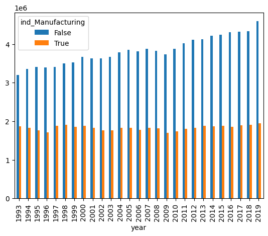

```python
# 複製資料集
df_ana_2 = df_ana.copy()
# 新增一個欄位，判斷是否為低技能工作
df_ana_2['IsLowSkill'] = (
    (df_ana_2['prof9_clerks'] == 1) |
     (df_ana_2['prof9_service'] == 1) |
     (df_ana_2['prof9_craftsmen'] == 1) |
     (df_ana_2['prof9_MachineOperators'] == 1) |
    ( df_ana_2['prof9_elementary'] == 1) )
# 將資料集依照年份、產業、是否為低技能工作，加總其各自的就業人數
grouped_df = df_ana_2.groupby(['year', 'ind_Manufacturing','IsLowSkill'])['weight'].sum()
#grouped_df = grouped_df.div(grouped_df.groupby(level=['year', 'ind_Manufacturing']).sum())
# 只取出低技能勞工的數據
grouped_df = grouped_df.xs(True, level='IsLowSkill')
# 將資料集重新組織，將產業的比例分別放在不同的欄位，以利繪製圖表
grouped_df = grouped_df.unstack()
# 繪製圖表
grouped_df.plot(kind='bar', stacked=False)
```

可以發現，製造業的低技術勞工數量無論在引進外勞政策實施之前或之後，都維持一定水準。但是非製造業的低技術勞工人數卻逐年上升。當使用非製造業作為對照組，就顯得製造業低技術勞工人數「相對減少」。

另一方面，我們也想透過觀察失業率在政策前後的變化，了解高低技術勞工是否在政策變動後退出勞動市場。

```python
# 載入另一個包含非勞動力的資料
import pathlib
data_unemployment_included_path = pathlib.Path("D:\MasterThesis\source\ManpowerUtilizationSurveyData\MainData_IncludeUnemployment.csv")
df_unemployment_included = pd.read_csv(data_unemployment_included_path)
df_unemployment_included.head()
```

|  | Unnamed: 0 | id | county | gender | age | marriage | labour1 | working_hour | ind | profession | ... | 2010 | 2011 | 2012 | 2013 | 2014 | 2015 | 2016 | 2017 | 2018 | 2019 |
| --- | --- | --- | --- | --- | --- | --- | --- | --- | --- | --- | --- | --- | --- | --- | --- | --- | --- | --- | --- | --- | --- |
| 0 | 0 | 20301423650010401 | 1.0 | 1.0 | 45.0 | 2.0 | 1.0 | 72.0 | 82.0 | 22.0 | ... | False | False | False | False | False | False | False | False | False | False |
| 1 | 1 | 20301423650020402 | 1.0 | 1.0 | 36.0 | 2.0 | 1.0 | 0.0 | 53.0 | 53.0 | ... | False | False | False | False | False | False | False | False | False | False |
| 2 | 2 | 20301423650020403 | 1.0 | 1.0 | 36.0 | 1.0 | 1.0 | 45.0 | 61.0 | 41.0 | ... | False | False | False | False | False | False | False | False | False | False |
| 3 | 3 | 20301423650020404 | 1.0 | 2.0 | 32.0 | 2.0 | 1.0 | 98.0 | 53.0 | 53.0 | ... | False | False | False | False | False | False | False | False | False | False |
| 4 | 4 | 20301423650030401 | 1.0 | 1.0 | 44.0 | 2.0 | 1.0 | 0.0 | 53.0 | 53.0 | ... | False | False | False | False | False | False | False | False | False | False |

5 rows × 51 columns

```python
labour_value_count = {}
for year in df_unemployment_included['year'].unique():
    sub_df = df_unemployment_included[df_unemployment_included['year'] == year].copy()
    sub_df['Unemployment'] = sub_df['labour1'].isin([4,5])
    labour_value_count[year] = sub_df.groupby(['Unemployment'])['weight'].sum()
df_value_count = pd.DataFrame(labour_value_count)
df_value_count
```

| Unemployment | 1993 | 1994 | 1995 | 1996 | 1997 | 1998 | 1999 | 2000 | 2001 | 2002 | ... | 2010 | 2011 | 2012 | 2013 | 2014 | 2015 | 2016 | 2017 | 2018 | 2019 |
| --- | --- | --- | --- | --- | --- | --- | --- | --- | --- | --- | --- | --- | --- | --- | --- | --- | --- | --- | --- | --- | --- |
| False | 8396350.0 | 8540460.0 | 8667604.0 | 8718362.0 | 9024235.0 | 9179065.0 | 9258923.0 | 9382929.0 | 9237014.0 | 9341447.0 | ... | 10274325.0 | 10499401.0 | 10642246.0 | 10770386.0 | 10870385.0 | 11007690.0 | 11078277.0 | 11161161.0 | 11251952.0 | 11318216.0 |
| True | 152807.0 | 170317.0 | 183555.0 | 260207.0 | 262340.0 | 245067.0 | 272346.0 | 280868.0 | 413418.0 | 491034.0 | ... | 526935.0 | 424824.0 | 422591.0 | 409214.0 | 399678.0 | 375272.0 | 393939.0 | 383454.0 | 379383.0 | 383854.0 |

2 rows × 27 columns

```python
labour_value_count = {}
for year in df_unemployment_included['year'].unique():
    sub_df = df_unemployment_included[df_unemployment_included['year'] == year].copy()
    sub_df['Unemployment'] = sub_df['labour1'].isin([4,5])
    unemployment = float(sub_df[sub_df['Unemployment'] == True]['weight'].sum())
    labour_force = float(sub_df['weight'].sum())
    labour_value_count[year] = unemployment / labour_force
# Convert the dictionary to a DataFrame and specify the index
df_value_count = pd.DataFrame(list(labour_value_count.items()), columns=['Year', 'Unemployment Rate'])
df_value_count.set_index('Year', inplace=True)
df_value_count
```

| Year | Unemployment Rate |
| --- | --- |
| 1993 | 0.017874 |
| 1994 | 0.019552 |
| 1995 | 0.020738 |
| 1996 | 0.028981 |
| 1997 | 0.028249 |
| 1998 | 0.026004 |
| 1999 | 0.028574 |
| 2000 | 0.029064 |
| 2001 | 0.042839 |
| 2002 | 0.049940 |
| 2003 | 0.049331 |
| 2004 | 0.042568 |
| 2005 | 0.039000 |
| 2006 | 0.036290 |
| 2007 | 0.036058 |
| 2008 | 0.035859 |
| 2009 | 0.056083 |
| 2010 | 0.048785 |
| 2011 | 0.038888 |
| 2012 | 0.038192 |
| 2013 | 0.036604 |
| 2014 | 0.035464 |
| 2015 | 0.032968 |
| 2016 | 0.034339 |
| 2017 | 0.033215 |
| 2018 | 0.032617 |
| 2019 | 0.032802 |

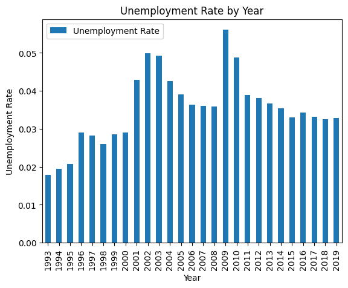

```python
# generate a plot to show the unemployment rate
df_value_count.plot(kind='bar')
# add an vertical line to indicate the policy implementation year : 2010
plt.axvline(x=2010, color='r', linestyle='--')
plt.title('Unemployment Rate by Year')
plt.xlabel('Year')
plt.ylabel('Unemployment Rate')
```

由上述資料可見，失業率反而有下降趨勢，而非如先前預期有升高趨勢。不過，由於2009全球金融風暴的緣故，政策實施前的失業率恐不能代表台灣經濟體的一般狀況。 比較謹慎的解讀方式則是比較金融風暴前的失業率與政策實施後的失業率。我們可以看到政策實施後的失業率略高於2005到2008的水準。 可是，由於我們並不瞭解金融風暴對經濟體組成的影響，我們難以說明這個差異肇因於引進外籍勞工的政策。

另一種可能的解釋是這些私人雇用者的從業身分改變了，他們可能轉變所謂的自雇工作者，成為家族小事業的幫手。這些人在受調查時不會成為失業人口，但是仍是離開私人雇用就業的一種方式。 所以我們嘗試檢視就業者中的各從業身分的比例是否有所改變。

```python
df = df_unemployment_included
df['EmployedIdentity'] = df['employed'].map({1:'Employer',2:'Self-employed',3:'gov-employed',4:'employee',5:'unpaid family worker'})

labour_value_count = {}
for year in df['year'].unique():
    sub_df = df[df['year'] == year].copy()
    sub_df['Unemployment'] = sub_df['labour1'].isin([4,5])
    unemployment = sub_df[sub_df['Unemployment'] == False].groupby(['EmployedIdentity'])['weight'].sum()
    labour_force = sub_df[sub_df['Unemployment'] == False]['weight'].sum()
    labour_value_count[year] = unemployment / labour_force
# Convert the dictionary to a DataFrame and specify the index
df_value_count = pd.DataFrame(labour_value_count)
df_value_count
```

| EmployedIdentity | 1993 | 1994 | 1995 | 1996 | 1997 | 1998 | 1999 | 2000 | 2001 | 2002 | ... | 2010 | 2011 | 2012 | 2013 | 2014 | 2015 | 2016 | 2017 | 2018 | 2019 |
| --- | --- | --- | --- | --- | --- | --- | --- | --- | --- | --- | --- | --- | --- | --- | --- | --- | --- | --- | --- | --- | --- |
| Employer | 0.050439 | 0.050690 | 0.050292 | 0.051492 | 0.054986 | 0.055633 | 0.054732 | 0.054540 | 0.051874 | 0.053134 | ... | 0.045852 | 0.045730 | 0.044701 | 0.043239 | 0.042111 | 0.041047 | 0.040106 | 0.039706 | 0.039244 | 0.039486 |
| Self-employed | 0.181795 | 0.178244 | 0.174411 | 0.173322 | 0.165386 | 0.159677 | 0.163658 | 0.160656 | 0.158937 | 0.160185 | ... | 0.128729 | 0.125134 | 0.123786 | 0.121717 | 0.119598 | 0.118881 | 0.118677 | 0.118074 | 0.117122 | 0.116351 |
| employee | 0.558731 | 0.566442 | 0.575570 | 0.568418 | 0.584039 | 0.601603 | 0.598895 | 0.607277 | 0.613705 | 0.613006 | ... | 0.668234 | 0.676700 | 0.682531 | 0.688263 | 0.692294 | 0.696010 | 0.697941 | 0.699822 | 0.702524 | 0.703801 |
| gov-employed | 0.119594 | 0.114887 | 0.111496 | 0.117704 | 0.113928 | 0.105685 | 0.103056 | 0.101335 | 0.102916 | 0.097935 | ... | 0.100764 | 0.097476 | 0.095448 | 0.094146 | 0.093301 | 0.092122 | 0.091475 | 0.090604 | 0.089915 | 0.089110 |
| unpaid family worker | 0.089442 | 0.089737 | 0.088230 | 0.089065 | 0.081661 | 0.077402 | 0.079659 | 0.076192 | 0.072568 | 0.075741 | ... | 0.056421 | 0.054960 | 0.053535 | 0.052635 | 0.052695 | 0.051940 | 0.051801 | 0.051795 | 0.051195 | 0.051252 |

5 rows × 27 columns

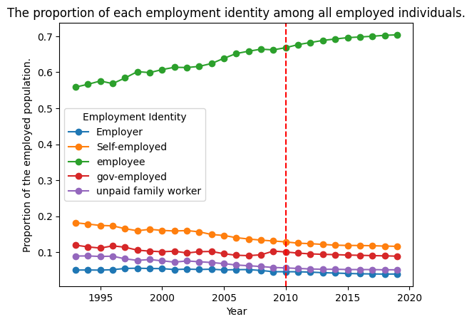

```python
# draw a line plot to show the unemployment rate by employment status
df_value_count.T.plot(kind='line', marker='o')
# add an vertical line to indicate the policy implementation year : 2010
plt.axvline(x=2010, color='r', linestyle='--')
plt.legend(title="Employment Identity")
# add a title and labels to the plot
plt.title('The proportion of each employment identity among all employed individuals.')
plt.xlabel('Year')
plt.ylabel('Proportion of the employed population.')
plt.show()
```

可以發現私人就業者的比例反而逐年增加，自雇工作者的比例逐年減少。但是在政策前後並無明顯變化。

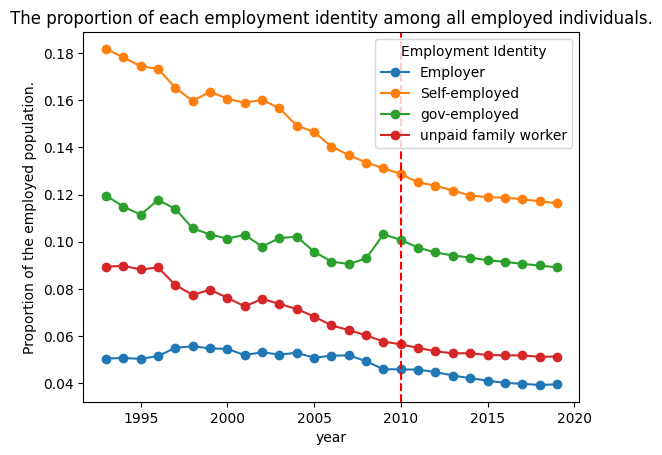

```python
# draw a line plot to show the unemployment rate by employment status
df_value_count.drop(index = ['employee']).T.plot(kind='line', marker='o')
# add an vertical line to indicate the policy implementation year : 2010
plt.axvline(x=2010, color='r', linestyle='--')
plt.legend(title="Employment Identity")
# add a title and labels to the plot
plt.title('The proportion of each employment identity among all employed individuals.')
plt.xlabel('year')
plt.ylabel('Proportion of the employed population.')
plt.show()
```

由於量級差距較大，為了方便觀察，我們排除受私人雇用者的資料重新作圖。但是並不影響結論：在政策前後，自雇工作者佔就業者整體比例並無明顯變化。

另一個較為迂迴的方式，則是就各個從業身分別，觀察其就業者的佔比。不過就資料解讀上較不直觀。

```python
df = df_unemployment_included
df['EmployedIdentity'] = df['employed'].map({1:'Employer',2:'Self-employed',3:'gov-employed',4:'employee',5:'unpaid family worker'})

labour_value_count = {}
for year in df['year'].unique():
    sub_df = df[df['year'] == year].copy()
    sub_df['Unemployment'] = sub_df['labour1'].isin([4,5])
    unemployment = sub_df[sub_df['Unemployment'] == False].groupby(['EmployedIdentity'])['weight'].sum()
    labour_force = sub_df.groupby(['EmployedIdentity'])['weight'].sum()
    labour_value_count[year] = unemployment / labour_force
# Convert the dictionary to a DataFrame and specify the index
df_value_count = pd.DataFrame(labour_value_count)
df_value_count
```

| EmployedIdentity | 1993 | 1994 | 1995 | 1996 | 1997 | 1998 | 1999 | 2000 | 2001 | 2002 | ... | 2010 | 2011 | 2012 | 2013 | 2014 | 2015 | 2016 | 2017 | 2018 | 2019 |
| --- | --- | --- | --- | --- | --- | --- | --- | --- | --- | --- | --- | --- | --- | --- | --- | --- | --- | --- | --- | --- | --- |
| Employer | 0.989588 | 0.987930 | 0.981711 | 0.979356 | 0.976699 | 0.981093 | 0.982202 | 0.984492 | 0.978037 | 0.983845 | ... | 0.981148 | 0.990480 | 0.995880 | 0.988156 | 0.987989 | 0.984326 | 0.992843 | 0.997093 | 0.980415 | 0.985790 |
| Self-employed | 0.988656 | 0.985445 | 0.985125 | 0.978742 | 0.982424 | 0.983823 | 0.984444 | 0.986868 | 0.978456 | 0.975418 | ... | 0.978311 | 0.982913 | 0.991281 | 0.984420 | 0.987502 | 0.990933 | 0.987758 | 0.993812 | 0.989331 | 0.987707 |
| employee | 0.975853 | 0.973551 | 0.973130 | 0.961872 | 0.962311 | 0.966246 | 0.960050 | 0.960438 | 0.941805 | 0.931600 | ... | 0.938646 | 0.951735 | 0.950826 | 0.954003 | 0.955375 | 0.958557 | 0.956661 | 0.956085 | 0.960484 | 0.960958 |
| gov-employed | 0.989093 | 0.993674 | 0.991591 | 0.988844 | 0.990873 | 0.988939 | 0.994430 | 0.988295 | 0.988200 | 0.980370 | ... | 0.968594 | 0.968005 | 0.974911 | 0.979943 | 0.978506 | 0.978884 | 0.979960 | 0.988085 | 0.974229 | 0.968374 |
| unpaid family worker | 0.995121 | 0.993690 | 0.991364 | 0.987398 | 0.989382 | 0.989733 | 0.995776 | 0.990608 | 0.987184 | 0.991019 | ... | 0.989379 | 0.994432 | 0.987448 | 0.991746 | 0.993298 | 0.994810 | 0.994046 | 0.994848 | 0.992471 | 0.992397 |

5 rows × 27 columns

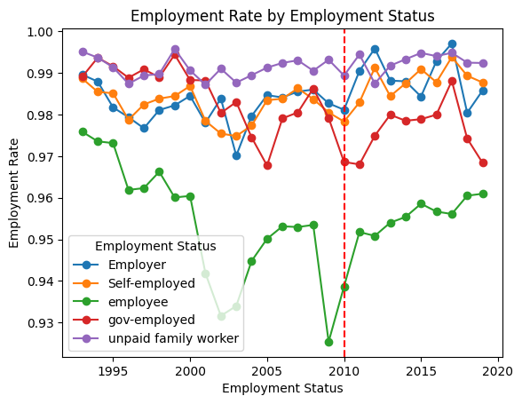

```python
# draw a line plot to show the unemployment rate by employment status
df_value_count.T.plot(kind='line', marker='o')
# add an vertical line to indicate the policy implementation year : 2010
plt.axvline(x=2010, color='r', linestyle='--')
plt.legend(title="Employment Status")
# add a title and labels to the plot
plt.title('Employment Rate by Employment Status')
plt.xlabel('Employment Status')
plt.ylabel('Employment Rate')
plt.show()
```

由上圖可以發現，私人雇用者比例在2010年後上升，並恢復到2005~2008年間的水準，與先前我們對失業率的分析一致。不過自雇工作者與雇主的就業比例，則在2010後來到了較2005~2008年間還要高的水準。 不過這種資料的解讀較不直觀。因為這些證據較不直接，退出市場假說暫且不採信，我們且看勞工轉移假說。

### 勞工轉移假說

```python
df_ana_3 = df_ana.copy()
df_ana_3['IsLowSkill'] = (
    (df_ana_3['prof9_clerks'] == 1) |
    (df_ana_3['prof9_service'] == 1) |
    (df_ana_3['prof9_craftsmen'] == 1) |
    (df_ana_3['prof9_MachineOperators'] == 1) |
    (df_ana_3['prof9_elementary'] == 1) )
# 'scale4_1_9' = 1 then Scale = 'small', ''scale4_10_199' = 1 then Scale = 'medium', 'scale4_200' = 1 then Scale = 'large', if all of them are 0 then Scale = 'large'
df_ana_3['Scale'] = np.select(
        [
            df_ana_3['scale4_1_9'] == 1,
            df_ana_3['scale4_10_199'] == 1,
            df_ana_3['scale4_200_499'] == 1,
            df_ana_3['scale4_500up'] == 1
        ],
        [
            'small',
            'medium',
            'large',
            'large'
        ],
        default='gov'  # This will be assigned if none of the conditions are met
    )
```

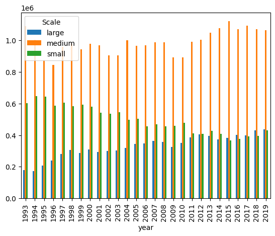

```python
# 畫出2005-2015年的各規模的長條圖，並就是否為低技能勞工分成兩張圖分別繪製
df_ana_3 = df_ana_3[df_ana_3['ind_Manufacturing'] == 1]
grouped_df = df_ana_3.groupby(['year','IsLowSkill','Scale'])['weight'].sum().unstack()
#去掉 Scale = 'gov' 的資料
grouped_df = grouped_df.drop(columns = ['gov'])
# 僅畫出低技能勞工的各規模的長條圖
grouped_df_low = grouped_df.xs(True, level='IsLowSkill')
grouped_df_low.plot(kind='bar')
```

製造業中，低技術勞工在中規模廠商中的就業人數最多，且在2011年後有上升趨勢；小規模廠商次之，但逐年減少；大規模廠商則逐年上升。

```python
df_ana_4 = df_ana.copy()
df_ana_4['IsLowSkill'] = (
    (df_ana_4['prof9_clerks'] == 1) |
    (df_ana_4['prof9_service'] == 1) |
    (df_ana_4['prof9_craftsmen'] == 1) |
    (df_ana_4['prof9_MachineOperators'] == 1) |
    (df_ana_4['prof9_elementary'] == 1) )
# 'scale4_1_9' = 1 then Scale = 'small', ''scale4_10_199' = 1 then Scale = 'medium', 'scale4_200' = 1 then Scale = 'large', if all of them are 0 then Scale = 'large'
df_ana_4['Scale'] = np.select(
        [
            df_ana_4['scale4_1_9'] == 1,
            df_ana_4['scale4_10_199'] == 1,
            df_ana_4['scale4_200_499'] == 1,
            df_ana_4['scale4_500up'] == 1
        ],
        [
            'small',
            'medium',
            'large',
            'large'
        ],
        default='gov'  # This will be assigned if none of the conditions are met
    )
```

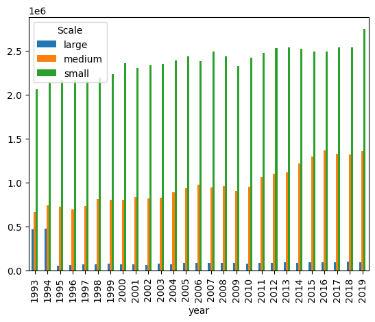

```python
# 畫出2005-2015年的各規模的長條圖，並就是否為低技能勞工分成兩張圖分別繪製
df_ana_4 = df_ana_4[df_ana_4['ind_Manufacturing'] == False]
grouped_df2 = df_ana_4.groupby(['year','IsLowSkill','Scale'])['weight'].sum().unstack()
#去掉 Scale = 'gov' 的資料
grouped_df2 = grouped_df2.drop(columns = ['gov'])
# 僅畫出低技能勞工的各規模的長條圖
grouped_df_low2 = grouped_df2.xs(True, level='IsLowSkill')
grouped_df_low2.plot(kind='bar')
```

非製造業中，低技術勞工的小規模廠商的就業人數最多，並逐年上升。中規模中的就業人數次之，同樣在2010年後人數上升。大規模就業人數最少。

```python
df_ana_4 = df_dummies.drop(columns = dummies_to_exclude + ['employed','county','ind16_name','IsMunicipality'])

df_ana_4.rename(columns=lambda x: 'col_' + x if x[0].isdigit() else x.replace('-', '_'), inplace=True) # pure digits string column names are not allowed.
df_ana_4['IsLowSkill'] = (
    (df_ana_4['prof9_clerks'] == 1) |
    (df_ana_4['prof9_service'] == 1) |
    (df_ana_4['prof9_craftsmen'] == 1) |
    (df_ana_4['prof9_MachineOperators'] == 1) |
    (df_ana_4['prof9_elementary'] == 1) )
df_ana_4['Wage'] = np.exp(df_ana_4['lnW'])
df_ana_4['Scale'] = np.select(
        [
            df_ana_4['scale4_1_9'] == 1,
            df_ana_4['scale4_10_199'] == 1,
            df_ana_4['scale4_200_499'] == 1,
            df_ana_4['scale4_500up'] == 1
        ],
        [
            'small',
            'medium',
            'large',
            'large'
        ],
        default='gov'  # This will be assigned if none of the conditions are met
    )
```

接著我們可以看看高低技術勞工在大小不同規模的薪資在各年度的變化。

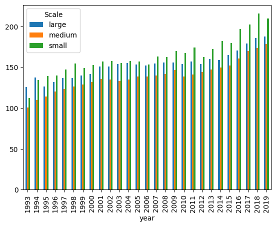

```python
df_ana_5 = df_ana_4[df_ana_4['ind_Manufacturing'] == 1].copy()
def weighted_wage(x):
    return x['Wage']*x['weight']
grouped_df = df_ana_5.groupby(['year','IsLowSkill','Scale']).apply(weighted_wage).groupby(level=['year', 'IsLowSkill', 'Scale']).sum()
grouped_df = grouped_df.div(df_ana_5.groupby(['year','IsLowSkill','Scale'])['weight'].sum())
grouped_df = grouped_df.unstack()
grouped_df = grouped_df.drop(columns = ['gov'])
grouped_df_low = grouped_df.xs(True, level='IsLowSkill')
grouped_df_low.plot(kind='bar')
```

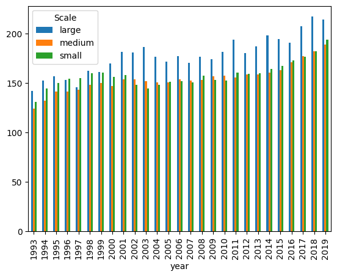

```python
df_ana_6 = df_ana_4[df_ana_4['ind_Manufacturing'] != 1].copy()
def weighted_wage(x):
    return x['Wage']*x['weight']
grouped_df = df_ana_6.groupby(['year','IsLowSkill','Scale']).apply(weighted_wage).groupby(level=['year', 'IsLowSkill', 'Scale']).sum()
grouped_df = grouped_df.div(df_ana_6.groupby(['year','IsLowSkill','Scale'])['weight'].sum())
grouped_df = grouped_df.unstack()
grouped_df = grouped_df.drop(columns = ['gov'])
grouped_df_low = grouped_df.xs(True, level='IsLowSkill')
grouped_df_low.plot(kind='bar')
```

我們發現，非製造業產業的低技術勞工中，於中小型廠商的就業人數最多，但是中小型廠商的薪資卻最低。我們認為這導致了DID結果呈現了製造業中低技術勞工薪資上升的結果。